# Desafio 5: Análises Avançados de Tipos de Dados Diversos

Entregar até 26/06/2020

Beatriz Milz

HTML compilado em: 30 de junho de 2020

```r
## Carregar pacotes

library(tidyverse) # pacote que inclui diversos pacotes para ciência de dados
library(readxl) # pacote para ler arquivos excel
library(purrr) # pacote para programação funcional
library(geobr) # pacote para usar mapas do Brasil
library(sf) # pacote para mapas
library(broom) # modelos
library(pdftools) #pacote para ler arquivos pdf
library(stringr) # pacote para trabalhar com texto
library(tidytext) # pacote para trabalhar com texto
library(textstem) # lidar com texto - stemização
library(wordcloud2) # nuvem de palavras
library(lexiconPT) # sentimento das palavras
```

## Roteiro

### Mapas

**1)** Instale e abre o pacote geobr do IBGE. Leia as instruções no site de github do pacote e use a função read_municipality() para acessar todos os municípios do estado de São Paulo em 2018.

```r
municipios_sp <- geobr::read_municipality("SP", year = 2018)
```

**2)** Use a funcionalidade da família de map para aplicar a função read_municipality para cinco estados em uma linha única de código: SP, RJ, MT, RS e RN (todos para o ano de 2018).

```r
cinco_estados <-  purrr::map_df(c("SP", "RJ", "MT", "RS", "RN"),
                                geobr::read_municipality, year = 2018)
```

**3)** Visualize um mapa simples usando ggplot dos municípios do estado de São Paulo. Formate o seu mapa e adicione um título. (Não precisa mostrar nenhum variável, só as fronteiras dos municípios).

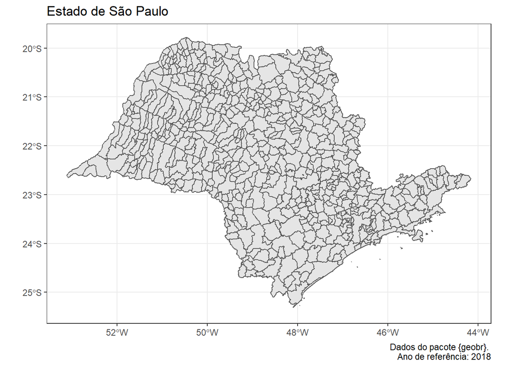

```r
municipios_sp %>%
  ggplot() +
  geom_sf() +
  theme_bw() +
  labs(title = "Estado de São Paulo", caption = "Dados do pacote {geobr}. \n Ano de referência: 2018")
```

**4)** Baixe, unzip e abre em R o arquivo da população paulista em 2010 do site do IBGE, ‘Censos’ -> ‘Censo_Demografico_2010’ -> ‘resultados’ -> ‘total_populacao_sao_paulo.zip’.

```r
total_populacao_sao_paulo <-
  read_excel("dados/total_populacao_sao_paulo.xls") %>%
  janitor::clean_names() # limpa o nome das variáveis
```

**5)** Queremos mapear dados da população por município. Identifique o chave apropriado, e cruze o banco de população com o banco das fronteiras dos municípios de SP.

```r
# A chave - coluna em comum - é relacionada ao código do município

# Essas duas variáveis precisam ser do mesmo tipo.
typeof(municipios_sp$code_muni) # double
```

```
## [1] "double"
```

```r
typeof(total_populacao_sao_paulo$codigo_do_municipio) #character
```

```
## [1] "character"
```

```r
# Não são. Precisa padronizar via mutate :) Aproveito e deixo com o mesmo nome de variável.

muni_sp_padronizado <- municipios_sp %>%
  mutate(codigo_do_municipio = as.character(code_muni))

# Usar left join e unir os dados

mapa_sp_populacao <-
  left_join(muni_sp_padronizado, total_populacao_sao_paulo)
```

**6)** Usando o seu banco de dados de Questão 5, calcule a proporção da população urbana na população total em cada município e visualize um mapa bem-formatado dessa taxa por município em 2010. Aplique uma escala de cores desejada.

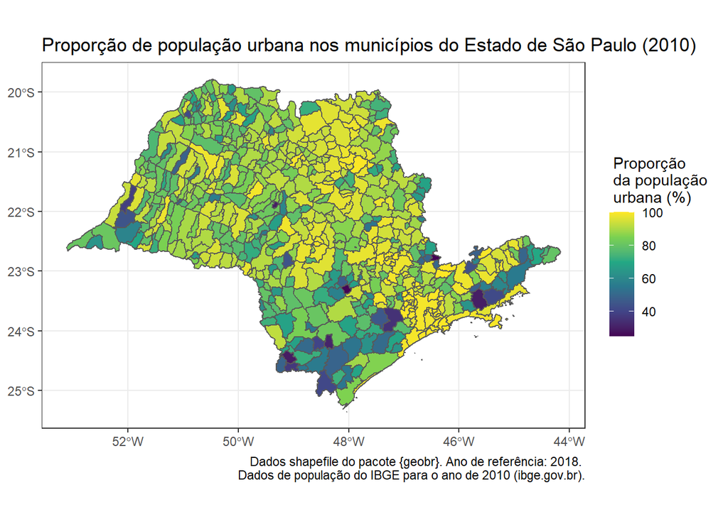

```r
mapa_sp_populacao %>%
  mutate(proporcao_pop_urbana = round(100 * total_da_populacao_urbana / total_da_populacao_2010, 2)) %>%
  ggplot() +
  geom_sf(aes(fill = proporcao_pop_urbana)) +
  scale_fill_continuous(type = "viridis") +
  theme_bw() +
  labs(title = "Proporção de população urbana nos municípios do Estado de São Paulo (2010)",
       caption = "Dados shapefile do pacote {geobr}. Ano de referência: 2018. \n Dados de população do IBGE para o ano de 2010 (ibge.gov.br).",
       fill = " Proporção \n da população \n urbana (%)")
```

**7)** Abre o shapeifle no arquivo MCMV_new.shp, que documenta a localização dos projetos de Minha Casa Minha Vida no Brasil, e o número de Unidades Habitacionais (UH) em cada projeto.

```r
mcmv <- st_read("dados/MCMV_new/MCMV_new.shp")
```

**8)** Verifique se a projeção (o CRS) dos dois bancos de dados espaciais (municípios e MCMV) são iguais, e, se necessário, padronize eles para um CRS da sua preferência.

```r
 # qual o sistema de referência?
st_crs(mcmv)
```

```
## Coordinate Reference System:
##   User input: WGS 84
##   wkt:
## GEOGCRS["WGS 84",
##     DATUM["World Geodetic System 1984",
##         ELLIPSOID["WGS 84",6378137,298.257223563,
##             LENGTHUNIT["metre",1]]],
##     PRIMEM["Greenwich",0,
##         ANGLEUNIT["degree",0.0174532925199433]],
##     CS[ellipsoidal,2],
##         AXIS["latitude",north,
##             ORDER[1],
##             ANGLEUNIT["degree",0.0174532925199433]],
##         AXIS["longitude",east,
##             ORDER[2],
##             ANGLEUNIT["degree",0.0174532925199433]],
##     ID["EPSG",4326]]
```

```r
st_crs(municipios_sp)
```

```
## Coordinate Reference System:
##   User input: SIRGAS 2000
##   wkt:
## GEOGCRS["SIRGAS 2000",
##     DATUM["Sistema de Referencia Geocentrico para las AmericaS 2000",
##         ELLIPSOID["GRS 1980",6378137,298.257222101,
##             LENGTHUNIT["metre",1]]],
##     PRIMEM["Greenwich",0,
##         ANGLEUNIT["degree",0.0174532925199433]],
##     CS[ellipsoidal,2],
##         AXIS["geodetic latitude (Lat)",north,
##             ORDER[1],
##             ANGLEUNIT["degree",0.0174532925199433]],
##         AXIS["geodetic longitude (Lon)",east,
##             ORDER[2],
##             ANGLEUNIT["degree",0.0174532925199433]],
##     USAGE[
##         SCOPE["unknown"],
##         AREA["Latin America - SIRGAS 2000 by country"],
##         BBOX[-59.87,-122.19,32.72,-25.28]],
##     ID["EPSG",4674]]
```

```r
municipios_sp_wgs84 <- municipios_sp %>% st_transform(4326)
```

**9)** Realize um spatial join para informar os dados de MCMV por município do estado de São Paulo, usando a localização dos projetos para juntar com os polígonos dos municípios.

```r
municipios_sp_mcmv <- st_join( municipios_sp_wgs84, mcmv)
```

**10)** Visualize um mapa do número de unidades habitacionais (UH) de MCMV por município de São Paulo (por polígono), e adicione uma segunda camada com a localização dos projetos de MCMV (os pontos). Formate o mapa e a escala de cores, e inclua um título.

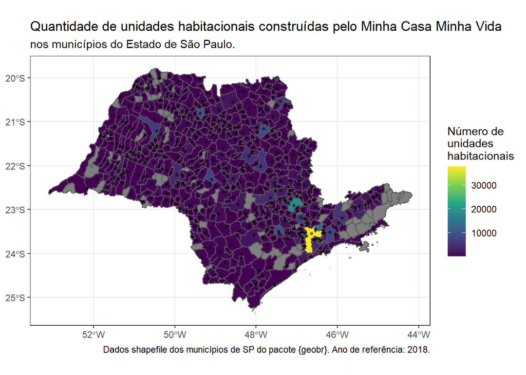

```r
mcmv_sp <- mcmv %>% filter(UF == "SP")

  ggplot() +
  geom_sf(data = municipios_sp_mcmv, aes(fill = UH)) +
  scale_fill_continuous(type = "viridis") +
  geom_sf(data = mcmv_sp, alpha = 0.5 , size = 1) +
 theme_bw() +
  labs(title = "Quantidade de unidades habitacionais construídas pelo Minha Casa Minha Vida",
        subtitle = "nos municípios do Estado de São Paulo.",
       caption = "Dados shapefile dos municípios de SP do pacote {geobr}. Ano de referência: 2018.",
       fill = "Número de \nunidades \nhabitacionais")
```

### Estatísticas e Programação funcional

**11)** Imagine que os nossos dados são apenas uma amostra de todos os projetos de MCMV, e o governo de São Paulo se compremeteu a construir exatamente uma média de 600 unidades habitacionais por município. Avalie com a nossa amostra disponível se eles atingiram este objetivo com um t-test da média.

```r
mcmv_sp %>%
  pull(UH) %>%
  t.test(mu=600)
```

```
##
##  One Sample t-test
##
## data:  .
## t = -0.91397, df = 563, p-value = 0.3611
## alternative hypothesis: true mean is not equal to 600
## 95 percent confidence interval:
##  341.4977 694.3250
## sample estimates:
## mean of x
##  517.9113
```

**12)** Queremos entender por que alguns municípios recebem mais unidades habitacionais (UH) do que outros. Execute uma regressão para avaliar se as seguintes variáveis são correlacionadas com o número de unidades habitacionais (UH): A taxa de população urbana e a população total em 2010. Mande o resultado para uma tabela bem-formatada.

```r
mapa_sp_pop_mcmv <- st_join(mapa_sp_populacao %>% st_transform(4326), mcmv_sp)

lm_mcmv <- lm(UH ~ total_da_populacao_2010 + total_da_populacao_urbana, data = mapa_sp_pop_mcmv)

lm_mcmv %>% tidy()
```

| term | estimate | std.error | statistic | p.value |
| --- | --- | --- | --- | --- |
| (Intercept) | 178.53774960 | 54.13893040 | 3.297770 | 0.001036256 |
| total_da_populacao_2010 | 0.03837914 | 0.01298120 | 2.956517 | 0.003242233 |
| total_da_populacao_urbana | -0.03499510 | 0.01311678 | -2.667964 | 0.007851834 |

**R:** As variáveis estão correlacionadas, municicípios com maior população recebem maiores unidades habitacionais do MCMV.

**13)** Mostre um gráfico dos efeitos marginais da regressão em Questão 12 - o tamanho dos dois coefficientes e os seus intervalos de confiança.

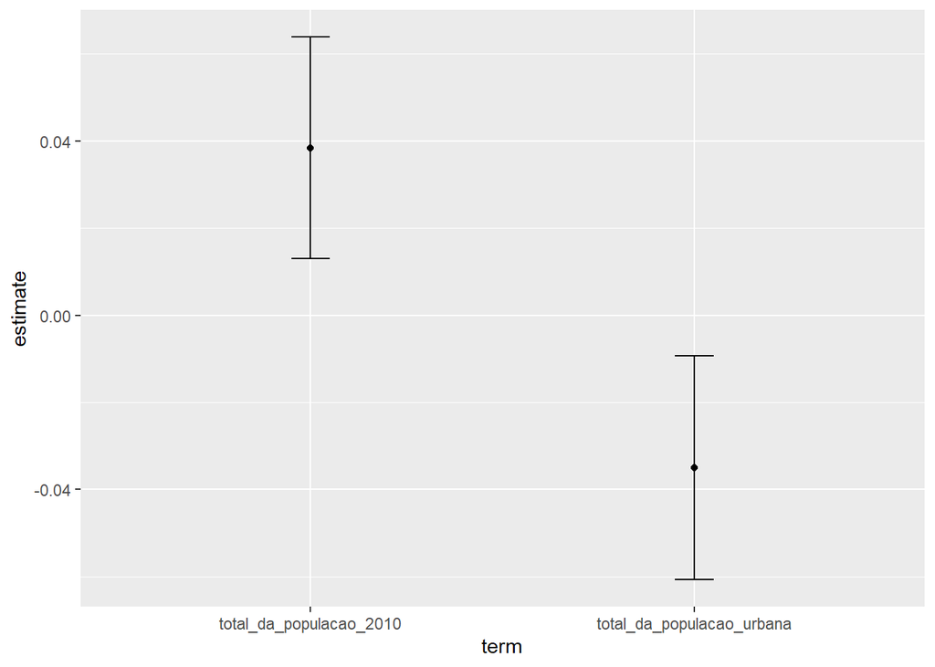

```r
lm_mcmv %>% tidy() %>%
  mutate(conf.lo=estimate-1.96*std.error,
         conf.hi=estimate+1.96*std.error) %>%
  filter(term!="(Intercept)") %>%
  ggplot() +
  geom_point(aes(x=term, y=estimate)) +
  geom_errorbar(aes(x=term, y=estimate, ymin=conf.lo, ymax=conf.hi), width=0.1)
```

**14)** Usando o banco de dados nacional de MCMV, use nest() para gerar um tibble ‘nested’ por estado. No seu tibble de resumo (com uma linha por estado) use a família de map para calcular o número de projetos em cada estado, e o número total de Unidades Habitacionais (UH) em cada estado como novas colunas.

```r
mcmv %>%
  group_by(UF)  %>%
  nest() %>%
  mutate(uh_estado = map(data, pull, UH),
         id_estado = map(data, pull, Project_ID),
         uh_soma = map_dbl(uh_estado, sum,  na.rm = TRUE),
         id_contagem = map_dbl(id_estado, length)
         ) %>%
  select(-id_estado, -uh_estado)
```

| UF | data | uh_soma | id_contagem |
| --- | --- | --- | --- |
| AC |  | 3844 | 10 |
| AM |  | 22348 | 54 |
| RO |  | 10141 | 46 |
| RR |  | 2351 | 6 |
| MT |  | 36043 | 91 |
| MS |  | 28402 | 73 |
| PA |  | 50285 | 99 |
| RS |  | 116779 | 480 |
| PR |  | 106876 | 377 |
| SC |  | 56806 | 282 |

[output cut: 17 more lines]

**15)** O ‘Project_ID’ é um indicador (um proxy) de quando o projeto foi iniciado. Vamos rodar uma regressão para avaliar se projetos mais recentes (com ‘Project_ID’ maior) contém mais Unidades Habitacionais (UH). Use a família map e o seu tibble nested de Questão 14 para aplicar uma regressão por estado, e guarde os coefficientes e os p-values das regressões em colunas novas do tibble de resumo.

```r
mcmv %>%
  group_by(UF)  %>%
  nest() %>%
  mutate(modelo =  map(data, ~lm(.x$UH ~ .x$Project_ID)),
         modelo_broom = map(modelo, broom::tidy),
        modelo_pvalue = map(modelo_broom, pull, p.value),
        modelo_estimate = map(modelo_broom, pull, estimate),
        modelo_term = map(modelo_broom, pull, term)
        ) %>%
  unnest(modelo_term, modelo_pvalue, modelo_estimate)
```

| UF | data | modelo | modelo_broom | modelo_pvalue | modelo_estimate | modelo_term |
| --- | --- | --- | --- | --- | --- | --- |
| AC |  |  |  | 7.734817e-01 | -2.036020e+02 | (Intercept) |
| AC |  |  |  | 3.332300e-01 | 4.941194e+01 | .x$Project_ID |
| AM |  |  |  | 9.333885e-01 | 4.521269e+01 | (Intercept) |
| AM |  |  |  | 4.045511e-01 | 5.531124e+00 | .x$Project_ID |
| RO |  |  |  | 2.276230e-01 | 4.028028e+02 | (Intercept) |
| RO |  |  |  | 5.686240e-01 | -2.990349e+00 | .x$Project_ID |
| RR |  |  |  | 7.691821e-01 | 1.753211e+03 | (Intercept) |
| RR |  |  |  | 8.189072e-01 | -1.482444e+01 | .x$Project_ID |
| MT |  |  |  | 1.701387e-02 | 5.487463e+02 | (Intercept) |
| MT |  |  |  | 3.696994e-01 | -5.249542e-01 | .x$Project_ID |

[output cut: 43 more lines]

### Análise de texto

**16)** Use o link aqui para acessar em R um PDF da discussão na Camara dos Deputados no dia 21 de Maio de 2020. Transforme o PDF em texto simples.

```r
url <- "https://escriba.camara.leg.br/escriba-servicosweb/pdf/59638"

texto_camara <- pdf_text(url) # cada página vira um elemento no vetor


texto_camara_pasted <-
  paste(texto_camara, collapse = " ") %>% # juntei todas as páginas em um único elemento. Assim não quebra por página.
  str_remove_all("Sessão de: 21/05/2020") %>% # retira texto que está em todas as páginas
  str_remove_all("Notas Taquigráficas") %>%  # retira texto que está em todas as páginas
  str_remove_all("CONGRESSO NACIONAL") %>%  # retira texto que está em todas as páginas
  str_remove_all("ORDEM DO DIA") %>% #divisões da ata
  str_remove_all("ENCERRAMENTO") %>% #divisões da ata
  str_replace_all("\r\n", " ") %>% #substitui \r\n por espaço.
  str_squish() # retira espaço desnecessário da string
```

**17)** Precisamos processar e preparar o texto para a análise. Segue os seguintes passos:

**17a)** Insera o texto num tibble

```r
tibble_camara <- texto_camara_pasted %>% as_tibble()
```

**17b)** No PDF é possível ver que as falas dos deputados distintos sempre começam com ‘O SR.’ ou ‘A SRA.’ então vamos usar estes strings para dividir o texto por Deputado. Use str_split para dividir o texto baseado nos strings ‘O SR.’ ou ‘A SRA.’ e gera uma nova coluna.

```r
camara_splited <-
  tibble_camara %>% mutate(separado = str_split(value, pattern = "O SR.|A SRA."))
```

**17c)** Em seguida, unnest() os dados para que cada fala de cada deputado é uma linha separado no tibble.

```r
camara_unested <- camara_splited %>% unnest(cols = c(separado)) %>% select(-value)
```

**17d)** Use separate para dividir a fala de cada deputado em duas colunas: O nome do Deputado, e o Discurso, usando o seguinte string como divisor: “\) -”

```r
discurso_1 <- camara_unested %>% separate(separado, into = c("nome", "discurso"), sep = "\\) - ") %>%
  filter(row_number() != 1)
```

**17e)** O resultado deve conter umas linhas em que a coluna ‘Deputado’ não é uma pessoa, mas começa com “Sessão”. Use filter para tirar essas linhas que começam com “Sessão” na coluna de ‘Deputado’.

Já fiz em códigos anteriores.

**17f)** Ainda, o nome do deputado fica desarrumado por causa de conteúdo em parenteses. Para identificar os deputados únicos, use separate para dividir a coluna do nome de Deputado em o nome e o conteúdo nos parenteses (que não importa para nos), usando o seguinte string como divisor: " \(".

```r
discurso_deputades <- discurso_1 %>% separate(nome, into = c("nome", "partido"), sep = " \\(") %>%
  mutate(deputade = case_when(
    nome == " PRESIDENTE" ~ "Presidente Marcos Pereira",
    TRUE ~ nome),
    nome = str_to_title(deputade)) %>%
  select(-deputade, -partido)
```

**17g)** Tire as colunas desnecessárias para que temos apenas as duas colunas: Nome do Deputado, e Discurso.

Já fiz em códigos anteriores.

**18)** Agora, com o tibble de Questão 17, vamos desaggregar e padronizar os discursos:

**18a)** ‘Tokenizar’ os discursos dos deputados em palavras únicas para que o seu tibble contém uma linha por palavra.

```r
token <- discurso_deputades %>% unnest_tokens(palavra, discurso, strip_numeric=TRUE)
```

**18b)** Tire os stopwords de português. Se quiser, pode incluir mais stopwords que você acha não relevante para a análise.

```r
stopwords <- get_stopwords(language="pt") %>%
  rename(palavra=word) %>% add_row(palavra = c("é", "nº", "sr"), lexicon="pessoal")

token_sem_stopwords <- token %>% anti_join(stopwords, by="palavra")

token_sem_stopwords %>% group_by(palavra) %>% count() %>% arrange(-n)
```

| palavra | n |
| --- | --- |
| presidente | 226 |
| deputado | 127 |
| governo | 82 |
| brasil | 78 |
| bolsonaro | 68 |
| momento | 67 |
| obrigado | 60 |
| senador | 59 |
| congresso | 55 |
| federal | 53 |

[output cut: 3628 more lines]

**18c)** Transforme as palavras em suas raízes, os ‘stems’.

```r
stem_deputades <-
  token_sem_stopwords %>%  mutate(stem = stem_words(palavra, language = "pt"))
```

**19)** Gere um ‘wordcloud’ dos stems das palavras usados pelos Deputados.

```r
stem_deputades %>% group_by(stem) %>% count(name = "freq") %>% # stems
wordcloud2()
```

[interactive chart not shown]

**20)** Execute uma análise de sentimento para identificar no documento inteiro qual Deputado que usa as palavras mais otimistas e qual Deputado usa as palavras mais pessimistas.

```r
sentimento <- oplexicon_v3.0 %>% select(term, polarity) %>%   rename(palavra=term)

polarity <- token_sem_stopwords  %>% inner_join(sentimento, by="palavra") # usando o inner join, palavras que nao tem polarity no dicionário são ignoradas

soma_polarity <- polarity %>% group_by(nome) %>% summarise(total_polaridade = sum(polarity, na.rm = TRUE)) %>% arrange(total_polaridade)


soma_polarity %>% slice(1, n())
```

| nome | total_polaridade |
| --- | --- |
| Presidente Marcos Pereira | -34 |
| Marcos Rogério | 45 |

**21)** No seu tibble de palavras e Deputados, gere um indicador binário da identidade do Deputado falando - se seja o Presidente da Câmara, ou qualquer outro Deputado (tratando todos juntos). Identifique as cinco palavras mais distintas de cada group (Presidente vs. outros).

```r
token_sem_stopwords %>%
  mutate(presidente = case_when(
    nome == "Presidente Marcos Pereira" ~ TRUE,
    TRUE ~ FALSE)
    ) %>%
  group_by(presidente, palavra) %>%
  tally() %>%
  bind_tf_idf(palavra, presidente, n) %>%
  ungroup() %>%
   group_by(presidente) %>%
  top_n(5, tf_idf)
```

| presidente | palavra | n | tf | idf | tf_idf |
| --- | --- | --- | --- | --- | --- |
| FALSE | bolsonaro | 68 | 0.006162211 | 0.6931472 | 0.004271319 |
| FALSE | brasil | 78 | 0.007068419 | 0.6931472 | 0.004899454 |
| FALSE | momento | 67 | 0.006071590 | 0.6931472 | 0.004208506 |
| FALSE | pandemia | 50 | 0.004531038 | 0.6931472 | 0.003140676 |
| FALSE | presidente | 226 | 0.020480290 | 0.6931472 | 0.014195855 |
| TRUE | acrescentando | 4 | 0.004032258 | 0.6931472 | 0.002794948 |
| TRUE | augusto | 4 | 0.004032258 | 0.6931472 | 0.002794948 |
| TRUE | cacá | 4 | 0.004032258 | 0.6931472 | 0.002794948 |
| TRUE | concedo | 5 | 0.005040323 | 0.6931472 | 0.003493685 |
| TRUE | coutinho | 4 | 0.004032258 | 0.6931472 | 0.002794948 |

[output cut: 4 more lines]